# Prosper: Fintech and new Lending Models

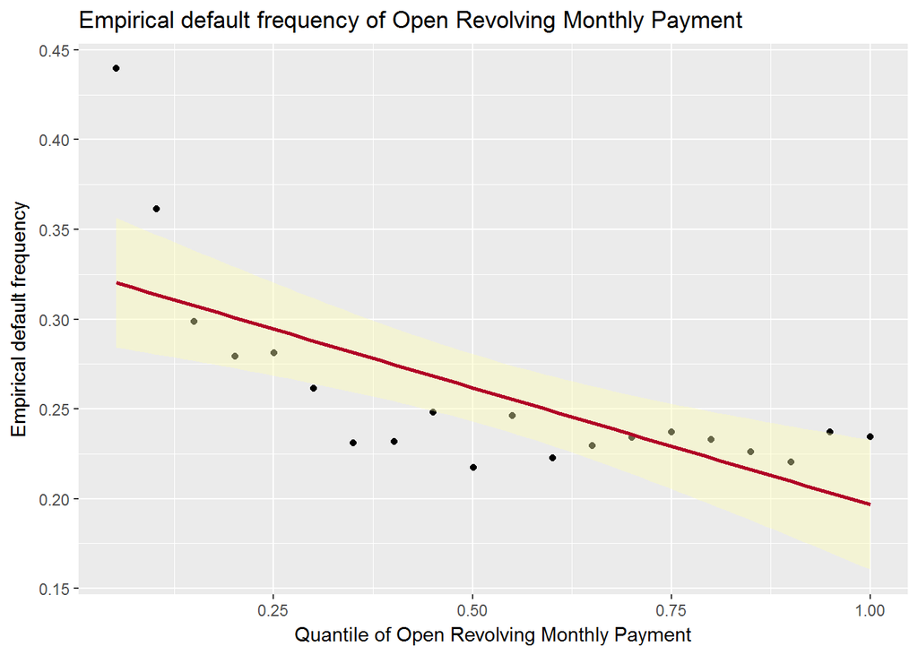

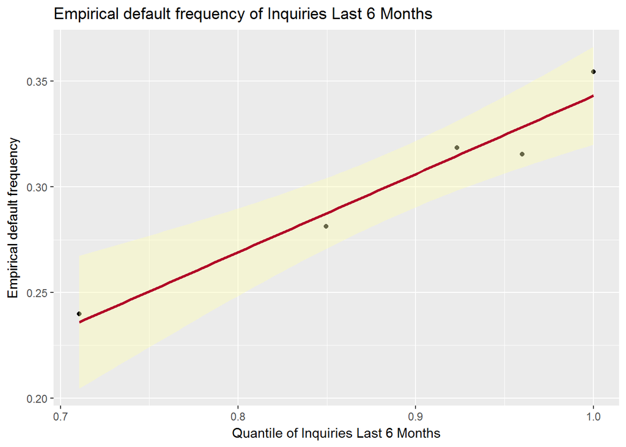

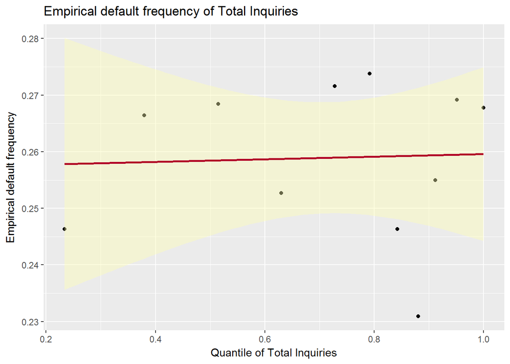

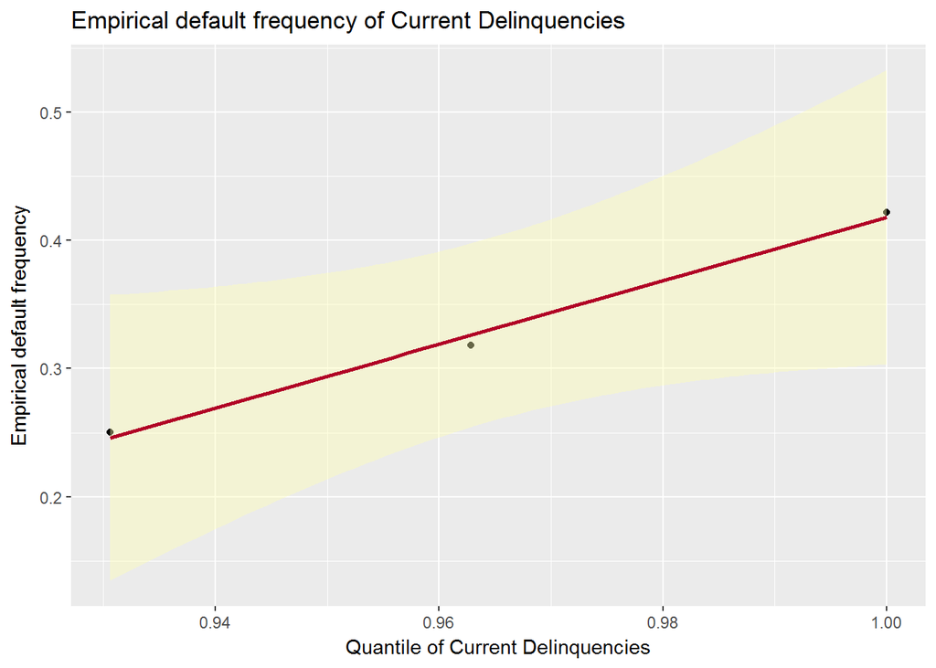

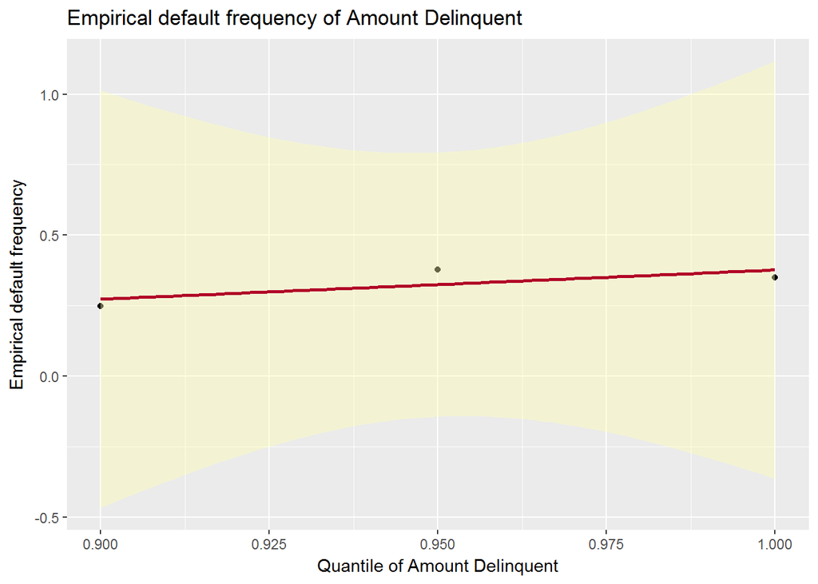

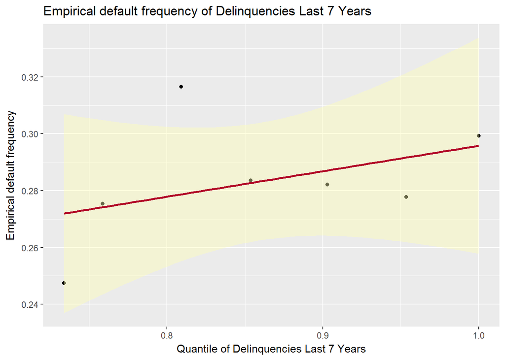

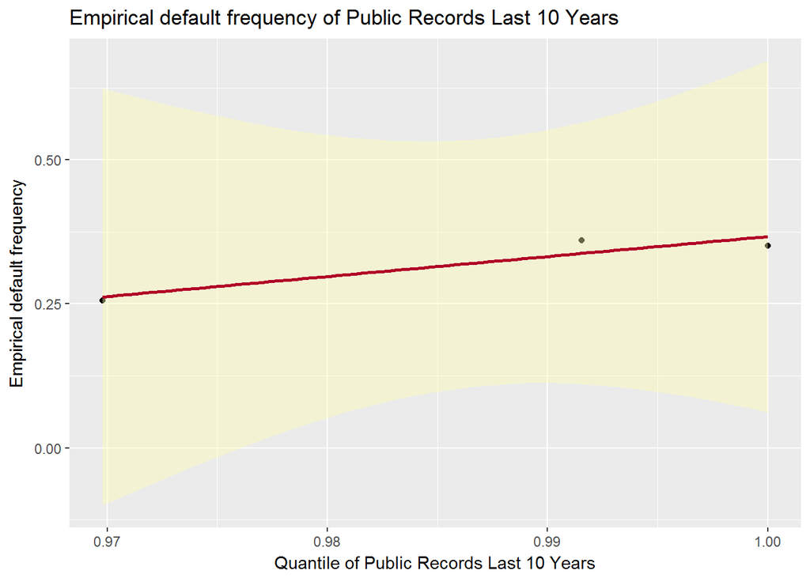

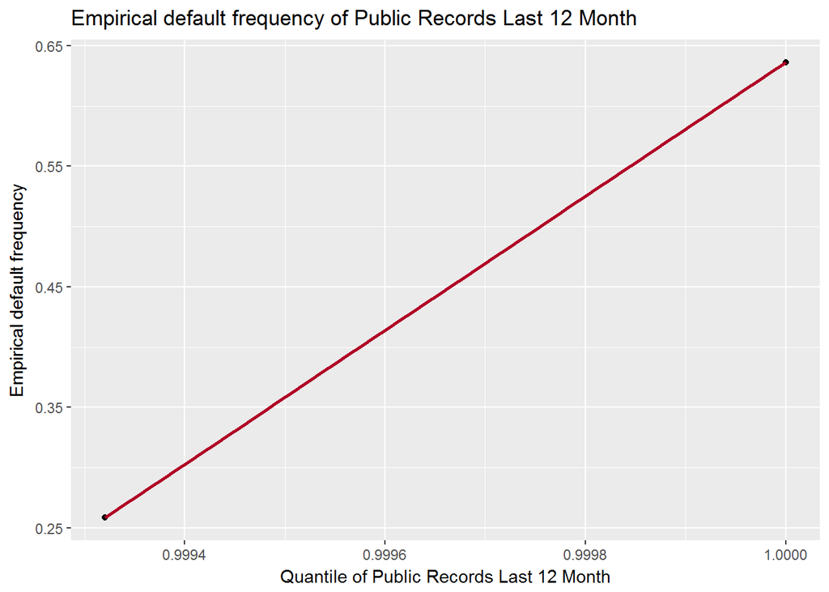

[7 more figures not shown]

The plots above give indications, how varied the empirical default frequency on variable concern the credit history and indebtedness, we highlighting linear relation. Although it would need to consider their combination to understand it. How the variable consider interact between them. The attention is for the variable with relation strongest, investigate multicollinearity phenomenon.

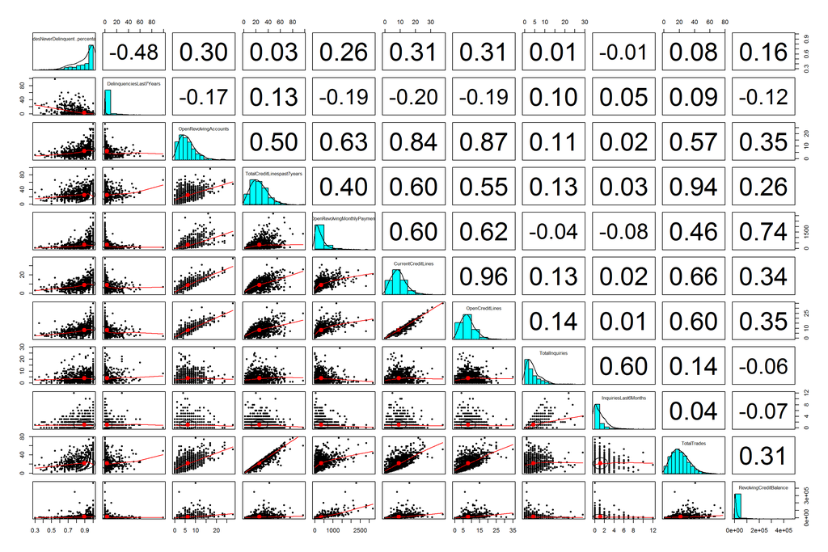

# Bivariate Analysis

### Talk about some of the relationships you observed in this part of the investigation. How did the feature(s) of interest vary with other features in the dataset?

In the investigation, we tried to understand how some variables, take singular, have on default rates.The variables of concern the borrower’s credit history and borrower indebtedness that provided from Credit Bureau and Prosper makes public. For every variable, we determine number of default and observations for particular percentile and then derive the corresponding empirical default frequency.

### Did you observe any interesting relationships between the other features (not the main feature(s) of interest)?

How the variables of concern the borrower’s credit history and borrower indebtedness are they are related to one another.

### What was the strongest relationship you found?

We observe strongest relationship between “CurrentCreditLines” and “OpenCreditLines”, “TotalTrades” and “TotalCreditLinespast7years”, “OpenRevolvingAccounts” and “OpenCreditLines”, “OpenRevolvingAccounts” and “CurrentCreditLines”, “RevolvingCreditBalance” and “OpenRevolvingMonthlyPayment”, “TotalTrades” and “CurrentCreditLines”, “CurrentCreditLines” and “TotalCreditLinespast7years”, “OpenRevolvingMonthlyPayment” and “OpenRevolvingAccounts”, “TotalTrades” and “OpenCreditLines”, “OpenRevolvingMonthlyPayment” and “OpenCreditLines”, “TotalInquiries” and “InquiriesLast6Months”, “TotalCreditLinespast7years” and “OpenCreditLines”, “OpenRevolvingMonthlyPayment” and “CurrentCreditLines”, “OpenRevolvingAccounts” and “TotalCreditLinespast7years”.

# Multivariate Plots Section

The range of Prosper Scores and Credit Scores are divided into multiple segments and combining them into a single grid and we procede to estimate base loss rate. We can make adjustments to the base loss rate to determine the final loss rate. The final loss rate determines the Proper Rating.  
Initially, we combine Prosper Scores and credit scores.

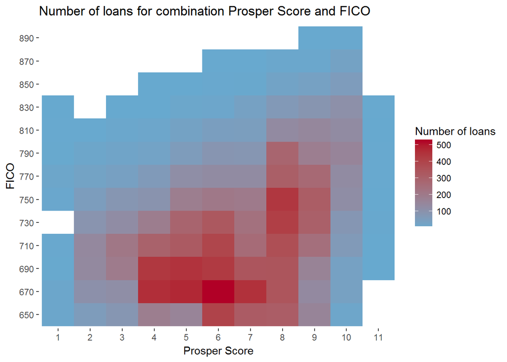

In the plot above, we observe numer of loans for each combine.

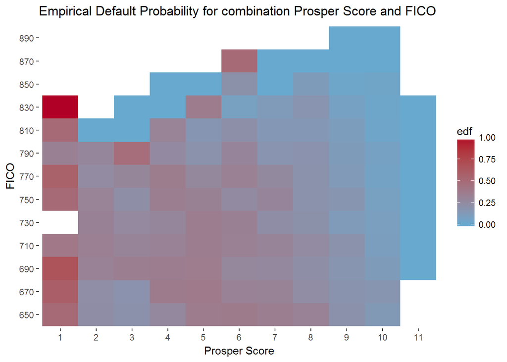

In this plot, we undestand the emprical default frenquency, edf, for each combine. Now, we have 120 combinations of “ProsperScore” and “FICO”, for each is assigned a value between 1 (the worst) and 120 (the best).

Therefore, we have new variable, “score” that combine with Prosper Rating.

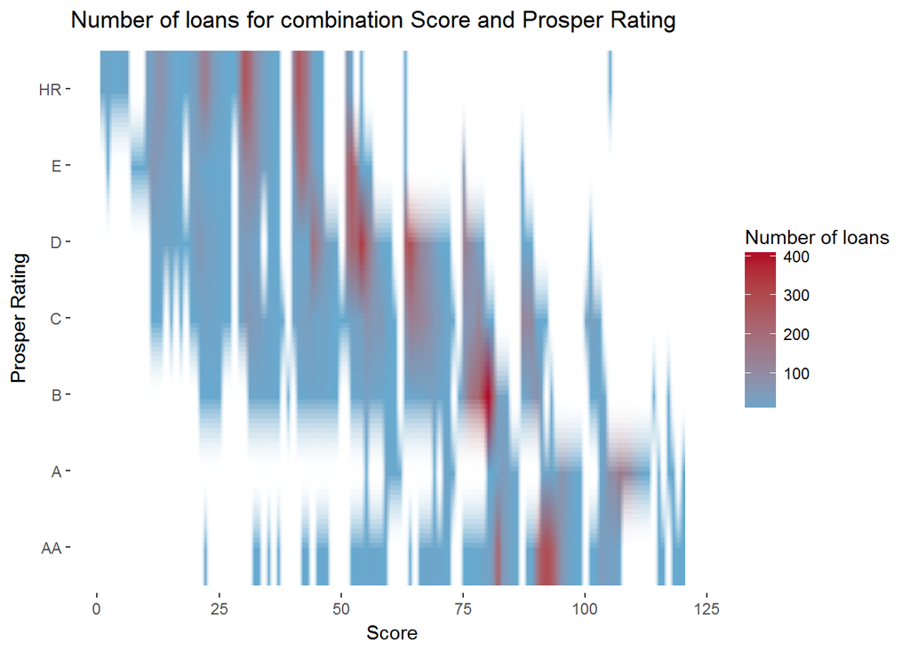

In the plot above, numer of loans for each combine.

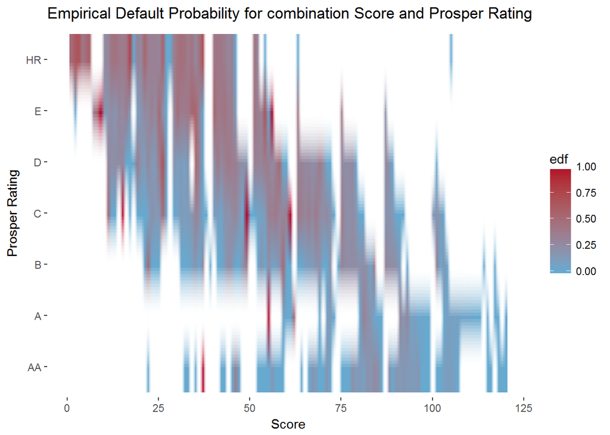

In this plot, we undestand the emprical default frenquency for each combine. Now, we estimate an explicit probability of default based on the variable that we consider. We are interested in modeling not continuous response variable but binary, Badloan, as function of one or more predictor variables. An generalized linear model, Logistic Regression, to accommodate responses that follow non-normal distributions. We perform operation of standardizing data of variables that we consider to understand if loan is “Good or”Bad“. This operation scaling variables in a similar range, we adopt”z-score standardization" procedure.

For each combination of combine Prosper Scores and credit scores associate mean estimate probability.

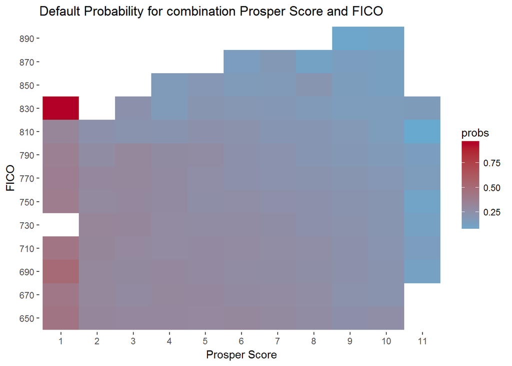

In the plot, we observe mean estimate probability for each combination. Now, we combine “score” variable and “ProsperRating..Alpha.”.

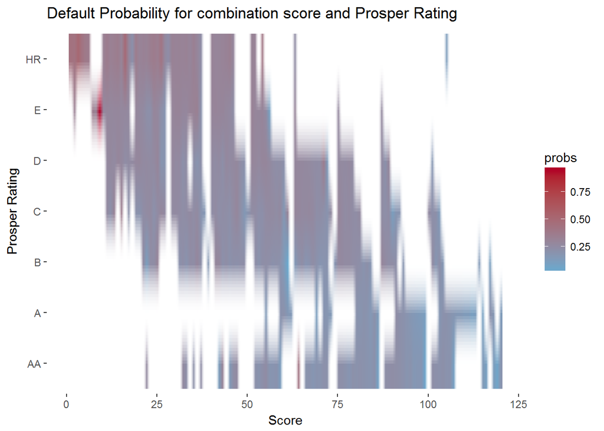

In the plot, we observe mean estimate probability for each combination.

# Multivariate Analysis

### Talk about some of the relationships you observed in this part of the investigation. Were there features that strengthened each other in terms of looking at your feature(s) of interest?

In this part, we investigate how the empirical default frequency change and estimate default probability between credit rating tiers.

### Were there any interesting or surprising interactions between features?

In the combination of rating credit, we investigated number of loans for each combination. We have loans with worst Prosper Score and best FICO at the same time. When we investigated empirical default probability and estimate default probability, loans with best credit rating tend to have small default probability and loans worst credit rating tend to have high default probability, as we expected. When we combine the loans by credit rating, the results are influenced the number loans each combination has.

### OPTIONAL: Did you create any models with your dataset? Discuss the strengths and limitations of your model.

We build a model for estimate an explicit probability of default based on the variable that we consider. In particular, the logit model, we use an linear regression model and adjusted through an exponential transformation, called the logistic transformation. The strengths that the range of values generated by the logistic functionis limited to the interval (0,1). This guarantees that the dependent variable y is always between 0 and 100%, and can therefore be correctly interpreted as a probability of default. Logistic regression attempts to predict outcomes based on a set of independent variables, it is necessary identified all the relevant independent variables,include the wrong independent variables, the model will have little to no predictive value. It is necessary consider multicollinearity exists, limit conclusions of study. Furthemore, Logit models are vulnerable to overfitting. It’s occurs when a model is excessively complex, such as having too many parameters relative to the number of observations. A model that has been overfit has poor predictive performance

# Final Plots and Summary

### Plot One

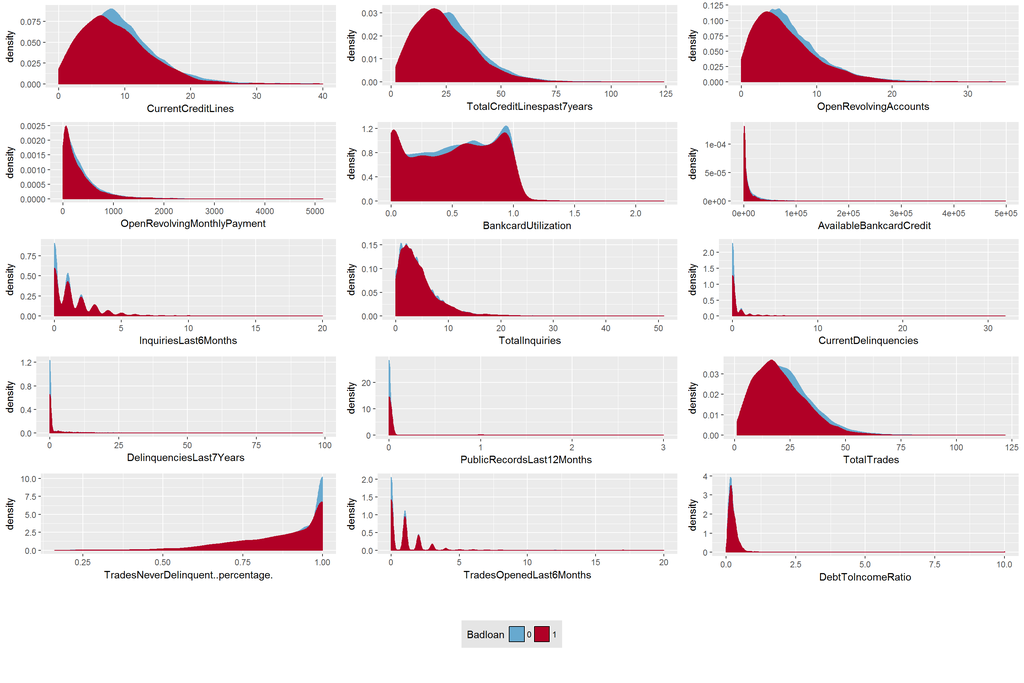

### Description One

For each variable Of best logistic model, we compare the distribution for “Bad” loans, 1, and, “Good” loans, 0. We observe plot, we derive that “Bad” loans and “Good” loans have different density plot and then we can conclude the features of loan have impact if it goes to default or not. However, the different attributes of loan must be considered together.

### Plot Two

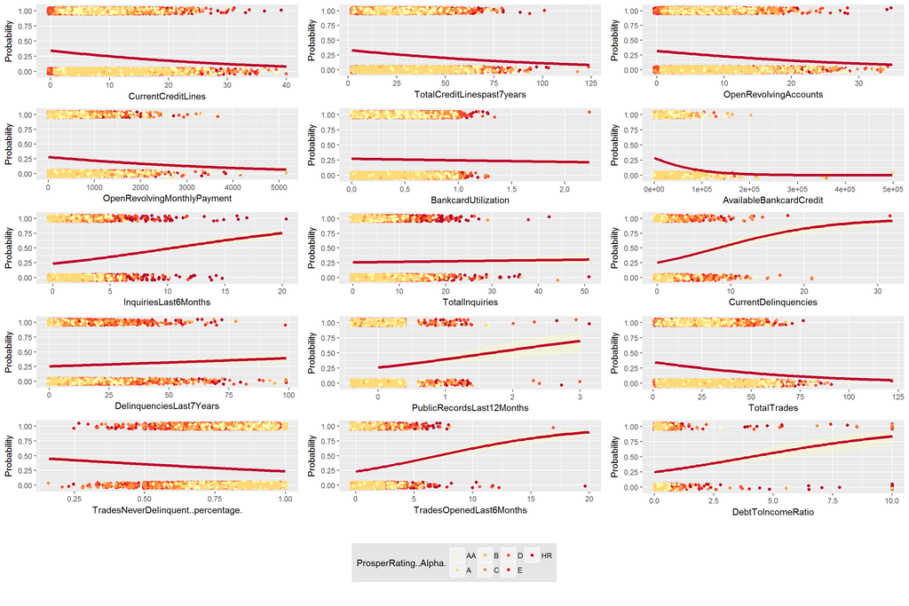

### Description Two

In the plot, for each variable for best logistic model we observe the logistic curve, how change the probability default to variable considered. Each variable have different impact on default of loans. Increasing the default probability, the class rating of loans tends to worsen. Furthermore, in the plot we can observe the class of rating for “bad”" loans, 1, and “Good”" loans, 0. The “Bad” loans tend to have worst class and “Good” loans to have best class, as we expected.

### Plot Three

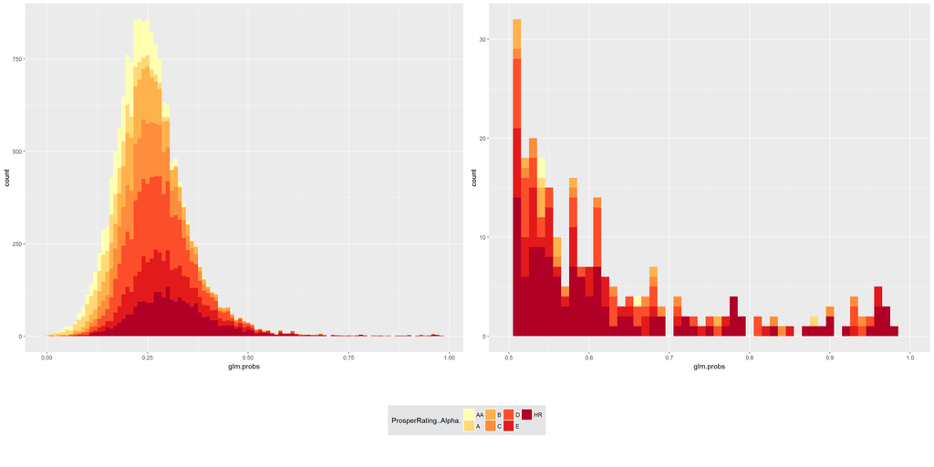

### Description Three

In the plot, we observe that the number of loans with low default probability are more than loans with hign default probability, this respect the economicity of credit activity. Furthemore, the loans with worst credit rating have highest default probability, as we expected.

# Reflection

In this analysis,initially, we have to understand Prosper Market and to find confirm on disbursed loans based on Prosper Prospectus. Then, we investigate the proprietary rating system Prosper. In particular, this system requires the estimate, first of all, of default probability and then expected loss. To do this, it is necessary various information. Prosper provides a series data of loans issued. Mainly,the investigation focused on the default rates. Specifically, understand some variables affect this rate. The goal is not derive a value of probability exact and precise. But rather, provided a series of information and elements to elaborate and develop reflection for structured models of credit scoring.